# 40/40 MENTOR MONTHY Updates

Marwa El Awik

2023-3-17

```r
library(tidyverse)
library(RColorBrewer)
library(plotly)
library(plyr)
library(gt)
library(stringr)
library(stringi)
library(mapquestr)
library(leaflet)
```

#### **About Dataset**

The dataset refers to 38 SGSF’ mentors. It includes monthly data collected by those mentors regarding their feedback over the mentorship program and their relationship with their mentees.

Looking ahead, of interest in this project will be to apply data preparation to be ready for further analysis, then to apply some EDA, to get all the information about our variable of interest, in addition to visualizing the data.

Here is a glimpse of what we will be working with.

```r
data<- readr::read_csv("40_40_MENTOR_MONTHY_Updates.csv")
```

```r
data<- data[c(2:6,9:15,18)]

##Fixing the colnames
names(data)[1] <- 'Month'
names(data)[4] <- 'Company Name'
names(data)[5] <- 'Company Zip Code'
names(data)[6] <- 'Area of STEM'
names(data)[7] <- 'Month goals as mentor'
names(data)[8] <- 'New ideas or areas my mentee would like to explore'
names(data)[9] <- 'Home zip code'
names(data)[10] <- 'Mentor-Mentee relationship rating'
names(data)[11] <- 'Gaps to fill'
names(data)[12] <- 'Outside opportunities provided'
names(data)[13] <- 'Growing impact rating'
```

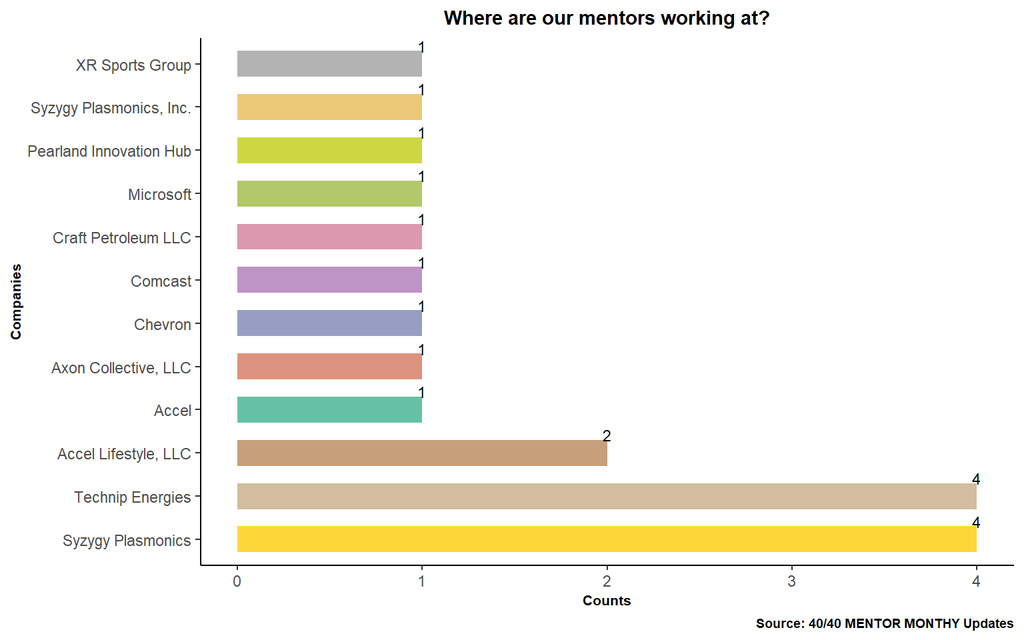

```r
T<-data%>% select(Month,`Company Name`)%>% group_by(Month)
T$`Company Name`[T$`Company Name`== "Syzygy"]<-"Syzygy Plasmonics"
T$`Company Name`[T$`Company Name`== "Technip Energies USA, Inc."]<-"Technip Energies"
T$`Company Name`[T$`Company Name`== "Accel Lifestyle"]<-"Accel Lifestyle, LLC"
Company_counts<- T %>% dplyr::count(`Company Name`)
max<-Company_counts  %>%
  group_by(`Company Name`) %>%
  slice(which.max(n))%>%
  arrange(desc(n))%>%drop_na()


colourCount = length(unique(max$`Company Name`))
getPalette = colorRampPalette(brewer.pal(colourCount, "Set2"))


p1<-ggplot(max, aes(x= reorder(max$`Company Name`, -max$n) , y=max$n, fill=max$`Company Name`,
                       text=paste("Grades distribution:",max$`Company Name`,
                                  "<br>Count:",max$n
                       )))+

  geom_bar(stat = 'identity',width = 0.6)+
  ggtitle("Where are our mentors working at?")+
  theme_classic()+
  theme(legend.position="none")+
  coord_flip()+
  labs(y="Counts",x="Companies", caption = "Source: 40/40 MENTOR MONTHY Updates") +
  theme(title = element_text(size = 9, face = "bold"),
        plot.title = element_text(hjust = 0.5),
        axis.title.x = element_text(size = 8, face = "bold"),
        axis.title.y = element_text(size = 8, face = "bold"),
        legend.position="none",
        panel.grid.minor = element_blank())+
  geom_text(aes(label = signif(max$n)),position=position_dodge(0.9),vjust = -1, size=3)

p1+scale_fill_manual(values = getPalette(colourCount))
```

- 4 Mentors work at Syzygy Plasmonics - 4 Mentors work at Technip Energies - 2 Mentors work at Accel Lifestyle

```r
companies_zipcodes<- data %>% select(`First Name`,`Company Zip Code`)%>% group_by(`First Name`)%>% unique()

library(zipcodeR)
geocode<-geocode_zip(companies_zipcodes$`Company Zip Code`)

m <- leaflet() %>%
  addTiles() %>%  # Add default OpenStreetMap map tiles
  addMarkers(lng= geocode$lng, lat=geocode$lat)
m
```

[interactive chart not shown]

The majority of our mentor’s working companies are located in Houston • 1 company is located in Dallas • 1 company is located in Detroit

```r
Home_zipcode<- data%>% select(`First Name`,`Home zip code`)%>% group_by(`First Name`)%>%
  unique()

library(zipcodeR)
geocode<-geocode_zip(Home_zipcode$`Home zip code`)

m <- leaflet() %>%
  addTiles() %>%  # Add default OpenStreetMap map tiles
  addMarkers(lng= geocode$lng, lat=geocode$lat)
m
```

[interactive chart not shown]

```r
data1 <- filter(data, data$Month == "Dec 2022")
relationship_rating_Dec<-count(data1$`Mentor-Mentee relationship rating`)
names(relationship_rating_Dec)[1]<-"Rating"



data2 <- filter(data, data$Month == "Jan 2023")
relationship_rating_Jan<-count(data2$`Mentor-Mentee relationship rating`)
names(relationship_rating_Jan)[1]<-"Rating"



data3 <- filter(data, data$Month == "Feb 2023")
relationship_rating_Feb<-count(data3$`Mentor-Mentee relationship rating`)
names(relationship_rating_Feb)[1]<-"Rating"


data4 <- filter(data, data$Month == "March 2023")
relationship_rating_Mar<-count(data4$`Mentor-Mentee relationship rating`)
names(relationship_rating_Mar)[1]<-"Rating"

data5 <- filter(data, data$Month == "April 2023")
relationship_rating_Apr<-count(data5$`Mentor-Mentee relationship rating`)
names(relationship_rating_Apr)[1]<-"Rating"

All_ratings<- full_join(relationship_rating_Dec,relationship_rating_Jan, by="Rating")%>%
  full_join(relationship_rating_Feb)
All_ratings<- full_join(All_ratings,relationship_rating_Mar, by="Rating")
All_ratings<- full_join(All_ratings,relationship_rating_Apr, by="Rating")

names(All_ratings)[2]<-"Dec"
names(All_ratings)[3]<-"Jan"
names(All_ratings)[4]<-"Feb"
names(All_ratings)[5]<-"Mar"
names(All_ratings)[6]<-"Apr"
```

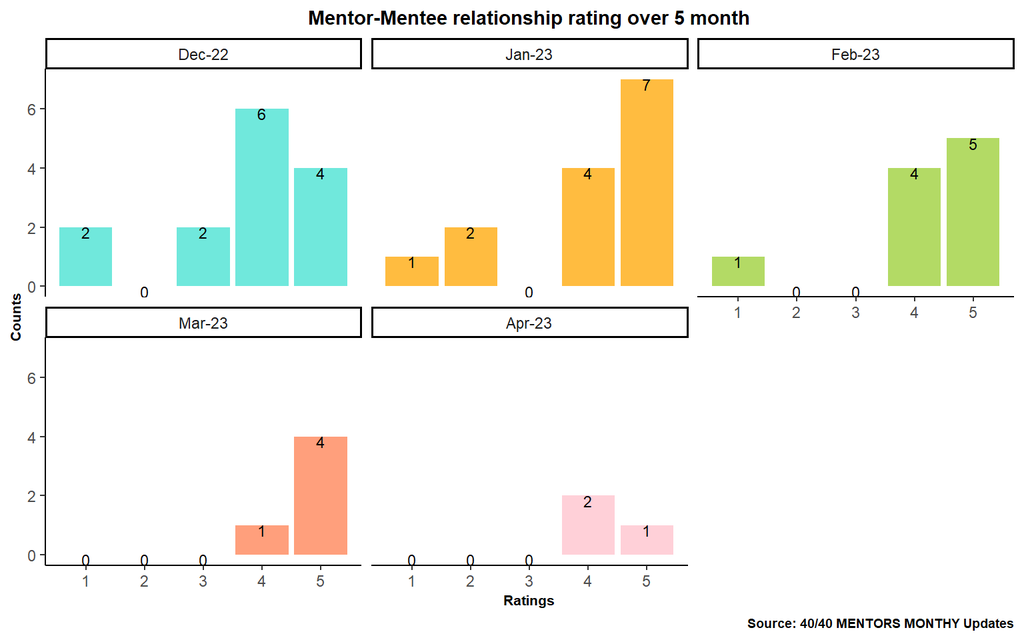

```r
data_ggp1 <- data.frame(Rating = All_ratings$Rating,                            # Reshape data frame
                       counts = c(All_ratings$Dec,All_ratings$Jan,All_ratings$Feb,All_ratings$Mar,All_ratings$Apr),
                       Month = c(rep("Dec-22", nrow(All_ratings)),
                                 rep("Jan-23", nrow(All_ratings)),
                                 rep("Feb-23", nrow(All_ratings)),
                                 rep("Mar-23", nrow(All_ratings)),
                                 rep("Apr-23", nrow(All_ratings))))

data_ggp1$Month  = factor(data_ggp1$Month, levels = c('Dec-22','Jan-23','Feb-23','Mar-23','Apr-23'))

data_ggp1<-data_ggp1 %>% replace(is.na(.), 0)

getPalette = colorRampPalette(brewer.pal(3, "Spectral"))

p2<-ggplot(data_ggp1,  aes(x= Rating, y=counts, fill= Month))+

  geom_bar(stat = 'identity',position=position_dodge(), alpha= 0.75)+
  ggtitle("Mentor-Mentee relationship rating over 5 month") +
  theme_classic()+
  facet_wrap(~Month)+
  geom_text(aes(label=counts), vjust=0.9,
            position=position_dodge(.9), size=3)+
    labs(y="Counts",x="Ratings", caption = "Source: 40/40 MENTORS MONTHY Updates")+

  theme(legend.position = "none",
       title = element_text(size = 9, face = "bold"),
        plot.title = element_text(hjust = 0.5),
        axis.title.x = element_text(size = 8, face = "bold"),
        axis.title.y = element_text(size = 8, face = "bold"),
        panel.grid.minor = element_blank())
p2 +scale_fill_manual(values = c("turquoise","orange1","yellowgreen","coral","pink"))
```

• There are switches in the relationship rating between Dec 22 and Apr 23 • The highest ratings account for 4 and 5 which is “ good” and “very good” respectively • Some of the mentors rated the relationship as 1 and 2 which is “very bad” and “bad” • Their is inequality of the mentors submitting reports.

```r
data1 <- filter(data, data$Month == "Dec 2022")
Growing_rating_Dec<-count(data1$`Growing impact rating`)
names(Growing_rating_Dec)[1]<-"Rating"


data2 <- filter(data, data$Month == "Jan 2023")
Growing_rating_Jan<-count(data2$`Growing impact rating`)
names(Growing_rating_Jan)[1]<-"Rating"


data3 <- filter(data, data$Month == "Feb 2023")
Growing_rating_Feb<-count(data3$`Growing impact rating`)
names(Growing_rating_Feb)[1]<-"Rating"

data4 <- filter(data, data$Month == "March 2023")
Growing_rating_Mar<-count(data4$`Growing impact rating`)
names(Growing_rating_Mar)[1]<-"Rating"

data5 <- filter(data, data$Month == "April 2023")
Growing_rating_Apr<-count(data5$`Growing impact rating`)
names(Growing_rating_Apr)[1]<-"Rating"

All_ratings<- full_join(Growing_rating_Dec,Growing_rating_Jan, by="Rating")%>%
  full_join(Growing_rating_Feb)%>% arrange(Rating)

All_ratings<- full_join(All_ratings,Growing_rating_Mar, by="Rating")
All_ratings<- full_join(All_ratings,Growing_rating_Apr, by="Rating")



names(All_ratings)[2]<-"Dec"
names(All_ratings)[3]<-"Jan"
names(All_ratings)[4]<-"Feb"
names(All_ratings)[5]<-"Mar"
names(All_ratings)[6]<-"Apr"
```

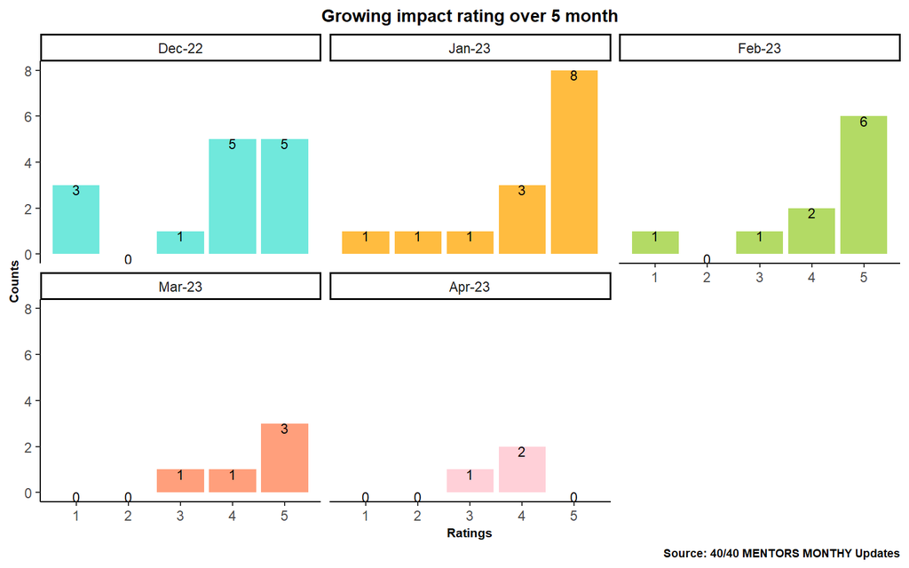

```r
data_ggp2 <- data.frame(Rating = All_ratings$Rating,                            # Reshape data frame
                       counts = c(All_ratings$Dec,All_ratings$Jan,All_ratings$Feb,All_ratings$Mar,All_ratings$Apr),
                       Month = c(rep("Dec-22", nrow(All_ratings)),
                                 rep("Jan-23", nrow(All_ratings)),
                                 rep("Feb-23", nrow(All_ratings)),
                                 rep("Mar-23", nrow(All_ratings)),
                                 rep("Apr-23", nrow(All_ratings))
                                 ))

data_ggp2$Month  = factor(data_ggp2$Month, levels = c('Dec-22','Jan-23','Feb-23','Mar-23','Apr-23'))

data_ggp2<-data_ggp2 %>% replace(is.na(.), 0)

getPalette = colorRampPalette(brewer.pal(3, "Spectral"))

p2<-ggplot(data_ggp2,  aes(x= Rating, y=counts, fill= Month))+

  geom_bar(stat = 'identity',position=position_dodge(), alpha= 0.75)+
  ggtitle("Growing impact rating over 5 month") +
  theme_classic()+
  facet_wrap(~Month)+
  geom_text(aes(label=counts), vjust=0.9,
            position=position_dodge(.9), size=3)+
    labs(y="Counts",x="Ratings", caption = "Source: 40/40 MENTORS MONTHY Updates")+

  theme(legend.position = "none",
       title = element_text(size = 9, face = "bold"),
        plot.title = element_text(hjust = 0.5),
        axis.title.x = element_text(size = 8, face = "bold"),
        axis.title.y = element_text(size = 8, face = "bold"),
        panel.grid.minor = element_blank())
p2 +scale_fill_manual(values = c("turquoise","orange1","yellowgreen","coral","pink"))
```

• There are switches in the impact rating between Dec 22 and Apr 23 • The highest ratings account for 4 and 5 which is “ good” and “very good” respectively • Some of the mentors rated the growing impact as 1 and 2 which is “very bad” and “bad” • There is inequality of the mentors submitting reports.

```r
library(dplyr)
Opportunities_Provided <- data%>% select(`Outside opportunities provided`)%>%drop_na()%>% filter(`Outside opportunities provided` != "Na",`Outside opportunities provided` != "NA at this time", `Outside opportunities provided` != "N/A", `Outside opportunities provided` != "-NA-",
                                                                                            `Outside opportunities provided` != "please contact my mentee and see if she is ok",
                                                                                            `Outside opportunities provided` !="Previously gave her my niece's contact information but she hasn't had a chance to follow up") %>% as.data.frame()%>%
  gt()%>%
  tab_header(title =md("**Outside opportunities offered to mentees by mentors**") ) %>%
  cols_label(`Outside opportunities provided`="Outside opportunities") %>%
  tab_source_note(source_note = md("**Source: 40/40 MENTORS MONTHY Updates**"))%>%



  tab_style(
    style=cell_text(font  = "calibri",
                    align = "center"),
    locations=cells_body(columns =c(`Outside opportunities provided`)
    ))%>%



  tab_style(
    style = list(
      cell_borders(
        sides = "bottom",
        color = "black",
        weight = px(2)
      )
    ),
    locations = list(
      cells_column_labels(
        columns = gt::everything()
      )
    )
  ) %>%

  tab_style(
    style = list(
      cell_text(font = "Karla", weight = "bold", align = "center")
    ),
    locations = list(
      cells_column_labels(gt::everything())
    )
  ) %>%

  tab_options(
    table.border.top.color = "black",
    table.border.bottom.color = "black",
    heading.border.bottom.color = "black",
    table_body.border.top.color = "black",
    column_labels.border.bottom.color = "white",
    table_body.hlines.color = "white",
    table_body.border.bottom.color = "black",
    row.striping.background_color = "black")
Opportunities_Provided
```

**Outside opportunities offered to mentees by mentors**

| Outside opportunities |
| --- |
| None yet - |
| A job and ampersand |
| I am connecting her to a person who is studying and working in the medical area. |
| I wrote a letter of recommendation for Lesly (for when she interviewed at The Motherhood Center). She got the job :) :) :) I am friends with the owner and asked if she needed any help for the summer a… |
| Ft Bend Academy resources |
| We are scheduling for March |
| I connected Joauna to Mercury Data Science, which is a local bioinformatics company |
| Talked to her extensively about internship opportunities with us this summer |
| ROCO |
| Business advice and guidance |
| I work part-time professional as a competitive college admissions advisor, so I was able to leverage my industry expertise there in helping her through her Baylor application. |
| Getting her in contact with a few of my engineering and nursing friends in specific fields she expressed interest in. Going to meet for coffee or early dinner with questions in a low key atmosphere fo… |
| Suggestions for scholarship and grant resources, tips for her college prep class, and professional orgs for her career of interest. |
| We discussed the differences between nylon and polyester |
| I will be able to introduce her to an US Tech (or multiple |
| Resume assistance, career guidance, industry knowledge (bought her a book on software development) |
| Invitation to "Women in Tech" Demo Day event and corresponding live stream video. |
| Connections to some of the universities of interest, networks/orgs of interest, and potential connections to more professionals in her fields of interest. |
| Programs she can participate in |
| None today other than a mentor she can discuss anything with! |
| Setting her up to speak with my niece who is a nurse |

**Source: 40/40 MENTORS MONTHY Updates**

The table shown above shows all the outside opportunities offered to our mentees by their mentors between Dec and Apr.

```r
library(dplyr)
Gaps_to_fill <- data%>% select(`Gaps to fill`)%>%drop_na()%>% filter(`Gaps to fill`!= "Na",`Gaps to fill`!= "na", `Gaps to fill`!= "N/A", `Gaps to fill`!= "N/a", `Gaps to fill`!= "n/a") %>% as.data.frame()%>%
  gt()%>%
  tab_header(title =md("**Gaps to fill**") ) %>%
  cols_label(`Gaps to fill`="Gaps to fill") %>%
  tab_source_note(source_note = md("**Source: 40/40 MENTORS MONTHY Updates**"))%>%



  tab_style(
    style=cell_text(font  = "calibri",
                    align = "center"),
    locations=cells_body(columns =c(`Gaps to fill`)
    ))%>%



  tab_style(
    style = list(
      cell_borders(
        sides = "bottom",
        color = "black",
        weight = px(2)
      )
    ),
    locations = list(
      cells_column_labels(
        columns = gt::everything()
      )
    )
  ) %>%

  tab_style(
    style = list(
      cell_text(font = "Karla", weight = "bold", align = "center")
    ),
    locations = list(
      cells_column_labels(gt::everything())
    )
  ) %>%

  tab_options(
    table.border.top.color = "black",
    table.border.bottom.color = "black",
    heading.border.bottom.color = "black",
    table_body.border.top.color = "black",
    column_labels.border.bottom.color = "white",
    table_body.hlines.color = "white",
    table_body.border.bottom.color = "black",
    row.striping.background_color = "black")

Gaps_to_fill
```

**Gaps to fill**

| Gaps to fill |
| --- |
| -NA- |
| She ended up getting let go from The Motherhood Center after a couple of weeks. She was working the front desk and wasn’t able to pick up the computer work very quickly. The owner also told me that sh… |
| -NA- |
| have more events for mentees |
| no communication |
| I have reached out twice to my mentee with no answer. |
| Things are going well! Our sessions have been on track, and we always end with a concrete deliverable. |
| It seems as though Daniella herself gets discouraged and doesnt feel like she can speak up in a room due to her introverted nature. Perhaps some kind of motivational workshop about self worth or knowi… |
| My background is not very helpful with her goal of owning her own clothing store / becoming a Business Manager |
| I have not heard anything from my mentee |
| I have not heard from my mentee in 2 months, despite email follow-ups |
| Only had one call/meeting, so still in initial stage of connecting. |
| No. We will meet via zoom this week. |
| Now that we connected we are good to go! |
| Slow response from mentee. Trying to set up a mtg in January, but depends on Cynthia's soccer schedule |

**Source: 40/40 MENTORS MONTHY Updates**

The table above shows all the gaps in the mentorship program that we need to fill.

**Recommendations/Room for improvement:** • Need to have all the Mentors submit their monthly reports. • Follow up with the Mentors that rated their mentor-mentee relationship less than 4 to check for any issues to solve. • Follow up with the Mentors that rated their mentorship growing impact on mentor rating less than 4 to check for any issues to solve. • Share the outside opportunities offered to mentees by mentors in our future presentation ( it reflects our impact) • Take the gaps to fill into consideration and take corrective action.